# Binary prediction

Andrew Maranhão

# Resumo

Iniciei esse desafio criando algumas features com base nos dados fornecidos. Apesar da abordagem clássica girar em torno de uma EDA, comecei criando um modelo baseline para então focar minha atenção nas features mais importantes.

Para sanar esse cenário, realizei uma EDA olhando feature à feature, selecionando as tidas como mais relevantes. Como resultado da EDA, identifiquei o leak como sendo fonte da depedência entre clientes e a eliminei.

A exploração do **leak garante uma auc de 0.9786** no holdout set e dado que o test set possui os mesmo clientes contidos no leak, sua auc também tende a ser alta - mas pela invalidade prática desse método, eu o descartei.

Em seguida submeti um modelo duplamente validado com uma rodada de cross validation e outra em um holdout set estratificado. Por fim, uma combinação linear de um Lightgbm com uma DNN feita em Keras geraram uma auc de 0.8886 usando apenas 8 features.

# Introdução

Vamos começar a EDA e Data Prep carregando algumas libs.

```r
library(data.table)
library(dplyr)
library(ggplot2)
library(ggthemes)
library(lubridate)
library(caTools)
library(ranger)
library(pROC)
library(caret)
setwd("~/Documents/XP Investimentos/real")
set.seed(451)

# [1] Read Data
raw.data  = fread("_transacao_train.csv")
test.data = fread("_transacao_test.csv")
additional.data = fread("_pessoas.csv")
```

# Preparação de Dados

Em seguida, vamos unir os dados, verificar a presença de `NAs` e ver as estatísticas descritivas dos dados.

```r
# [2] Join training data with pessoas df
raw.data  = merge(raw.data, additional.data,  by="ID")
test.data = merge(test.data, additional.data, by="ID")

# [3] Isolate labels
label = raw.data$retorno
raw.data$retorno = NULL

# [4] Clone data for safekeeping
full.data  = raw.data
glimpse(full.data)
```

```
## Observations: 1,939,676
## Variables: 44
## $ ID        <chr> "cli_100", "cli_100", "cli_100002", "cli_100002", "c...
## $ data.x    <chr> "2022-09-27", "2022-09-27", "2022-11-23", "2022-11-2...
## $ categoria <chr> "tipo2", "tipo2", "tipo2", "tipo2", "tipo4", "tipo2"...
## $ var10.x   <chr> "type 1", "type 1", "type 1", "type 1", "type 894", ...
## $ var1      <chr> "tipo2", "tipo2", "tipo2", "tipo2", "tipo2", "tipo2"...
## $ grupo     <chr> "group 17304", "group 17304", "group 8688", "group 8...
## $ var2      <chr> "tipo2", "tipo2", "tipo3", "tipo3", "tipo3", "tipo3"...
## $ data.y    <chr> "2021-06-29", "2021-06-29", "2021-01-06", "2021-01-0...
## $ var3      <chr> "tipo5", "tipo5", "tipo28", "tipo28", "tipo4", "tipo...
## $ var4      <chr> "tipo5", "tipo5", "tipo9", "tipo9", "tipo8", "tipo8"...
## $ var5      <chr> "tipo5", "tipo5", "tipo5", "tipo5", "tipo5", "tipo5"...
## $ var6      <chr> "tipo3", "tipo3", "tipo3", "tipo3", "tipo2", "tipo2"...
## $ var7      <chr> "tipo11", "tipo11", "tipo11", "tipo11", "tipo5", "ti...
```

[output cut: 31 more lines]

```r
# [5] Check NAs
colSums(is.na(full.data))
```

```
##        ID    data.x categoria   var10.x      var1     grupo      var2
##         0         0         0         0         0         0         0
##    data.y      var3      var4      var5      var6      var7      var8
##         0         0         0         0         0         0         0
##      var9   var10.y     var11     var12     var13     var14     var15
##         0         0         0         0         0         0         0
##     var16     var17     var18     var19     var20     var21     var22
##         0         0         0         0         0         0         0
##     var23     var24     var25     var26     var27     var28     var29
##         0         0         0         0         0         0         0
##     var30     var31     var32     var33     var34     var35     var36
##         0         0         0         0         0         0         0
##     var37     var38
##         0         0
```

```r
# [] Check stats
summary(full.data)
```

```
##       ID               data.x           categoria
##  Length:1939676     Length:1939676     Length:1939676
##  Class :character   Class :character   Class :character
##  Mode  :character   Mode  :character   Mode  :character
##
##
##
##    var10.x              var1              grupo
##  Length:1939676     Length:1939676     Length:1939676
##  Class :character   Class :character   Class :character
##  Mode  :character   Mode  :character   Mode  :character
##
##
##
##      var2              data.y              var3
##  Length:1939676     Length:1939676     Length:1939676
##  Class :character   Class :character   Class :character
##  Mode  :character   Mode  :character   Mode  :character
##
##
##
##      var4               var5               var6
##  Length:1939676     Length:1939676     Length:1939676
##  Class :character   Class :character   Class :character
##  Mode  :character   Mode  :character   Mode  :character
##
##
##
##      var7               var8               var9            var10.y
##  Length:1939676     Length:1939676     Length:1939676     Mode :logical
##  Class :character   Class :character   Class :character   FALSE:1468501
##  Mode  :character   Mode  :character   Mode  :character   TRUE :471175
##
##
##
##    var11           var12           var13           var14
##  Mode :logical   Mode :logical   Mode :logical   Mode :logical
##  FALSE:1538304   FALSE:1482703   FALSE:1258555   FALSE:1442953
##  TRUE :401372    TRUE :456973    TRUE :681121    TRUE :496723
##
```

[output cut: 29 more lines]

```
##
##    var31           var32           var33           var34
##  Mode :logical   Mode :logical   Mode :logical   Mode :logical
##  FALSE:1416344   FALSE:1418115   FALSE:1522105   FALSE:1265765
##  TRUE :523332    TRUE :521561    TRUE :417571    TRUE :673911
##
##
##
##    var35           var36           var37             var38
##  Mode :logical   Mode :logical   Mode :logical   Min.   :  0.00
##  FALSE:1547481   FALSE:1299394   FALSE:1410929   1st Qu.:  0.00
##  TRUE :392195    TRUE :640282    TRUE :528747    Median : 59.00
##                                                  Mean   : 49.93
##                                                  3rd Qu.: 82.00
##                                                  Max.   :100.00
```

Agora, criaremos algumas features baseadas nas datas fornecidas.

```r
# [] Create time-based features
full.data$data.x = as.Date(full.data$data.x, format='%Y-%m-%d')
full.data$data.y = as.Date(full.data$data.y, format='%Y-%m-%d')

full.data$weekday_x = wday(full.data$data.x)
full.data$weekday_y = wday(full.data$data.y)

full.data$numday_x = day(full.data$data.x)
full.data$numday_y = day(full.data$data.y)

full.data$month_x  = month(full.data$data.x)
full.data$month_y  = month(full.data$data.y)

full.data$year_x   = year(full.data$data.x) - 2018
full.data$year_y   = year(full.data$data.y) - 2018

full.data$time_dif = as.numeric(full.data$data.x) - as.numeric(full.data$data.y)
```

Já que os dados são anônimos, é necessário analisar as features para descobrir qual sua natureza:

```r
# [] Inspect Cardinality
cardinality = function(x){
  x = x %>% as.data.frame()
  for (j in 1:ncol(x)){
    print(paste0(colnames(x)[j],": ",length(unique(x[,j])), " dtype:",class(x[,j])))
  }
}

cardinality(full.data)
```

```
## [1] "ID: 133176 dtype:character"
## [1] "data.x: 356 dtype:Date"
## [1] "categoria: 6 dtype:character"
## [1] "var10.x: 6239 dtype:character"
## [1] "var1: 2 dtype:character"
## [1] "grupo: 27325 dtype:character"
## [1] "var2: 3 dtype:character"
## [1] "data.y: 1165 dtype:Date"
## [1] "var3: 43 dtype:character"
## [1] "var4: 25 dtype:character"
## [1] "var5: 9 dtype:character"
## [1] "var6: 7 dtype:character"
## [1] "var7: 25 dtype:character"
## [1] "var8: 8 dtype:character"
## [1] "var9: 9 dtype:character"
```

[output cut: 38 more lines]

Com as features compreendidas, chegou a hora de tratá-las adequadamente. A `var1` possui 2 valores únicos e foi interpretada como categórica, logo podemos torna-la binária.

Criaremos também features summarizando a contagem e os retornos passados de cada cliente, similar a uma whitelist/blacklist - Estas serão cruciais mais a frente.

```r
# [] Convert var1 to binary
full.data$var1 = ifelse(full.data$var1 == "tipo2",1,0)

# [] Create count list and past results list
full.data$retorno = label
count_list  = full.data  %>% group_by(ID) %>% summarize(count = n())
past_result = full.data  %>% group_by(ID) %>% summarize(past_result = mean(retorno))


# [] Add these variables in the main dataset
full.data = merge(full.data, count_list,  by="ID")
full.data = merge(full.data, past_result, by="ID")
```

# Análise Exploratória

A esse ponto, eu criei um modelo baseline - um randomforest de 100 árvores treinado com acurácia, obtendo uma auc de apenas 0.608, levando mais de 30 minutos para rodar.

O contraste entre as features de importância do modelo baseline com a EDA foram essenciais para a seleção de variáveis, bem como para a descoberta do **leak**

```r
# Obs: Os modelos não serão executados no Rmarkdown, já que isso significaria a necessidade de pelo menos mais 1 hora!
# [] Baseline model
rf.model = ranger(retorno ~ ., data=train, importance = 'impurity', num.trees=100)

rf.pred = predict(rf.model, probe)
table(probe$retorno, rf.pred$predictions >= 0.5)

# [] Calculate auc
glmnet::auc(probe$retorno, rf.pred$predictions) #0.6085423
```

Com novas features criadas, vamos realizar a seleção das features que mais sensibilizam a variável de efeito. Existem interações entre variáveis explicatórias, mas elas não foram levadas em conta por economia de tempo.

```r
# [] Helper Functions for EDA
quickplot_density = function(variable){
  ggplot(full.data, aes(x=variable, fill=as.factor(retorno)))+
    geom_density(color="white",alpha=0.8)+
    theme_hc(bgcolor = 'darkunica')+
    ggtitle(paste0(substr(deparse(substitute(variable)),11,99)," vs Retorno"))
}

quickplot_bar = function(variable){
  ggplot(full.data, aes(x=variable, y=1, fill=as.factor(retorno)))+
    geom_bar(stat="identity",position='fill',alpha=0.8)+
    theme_hc(bgcolor = 'darkunica')+
    ggtitle(paste0(substr(deparse(substitute(variable)),11,99)," vs Retorno"))
}


quickplot_boxplot = function(variable){
  ggplot(full.data, aes(x=variable, y=1, fill=as.factor(retorno)))+
    geom_boxplot(color="white",alpha=0.8)+
    theme_hc(bgcolor = 'darkunica')+
    ggtitle(paste0(substr(deparse(substitute(variable)),11,99)," vs Retorno"))
}

quickplot_violin = function(variable){
ggplot(full.data, aes(x=variable,y=var38))+
  geom_violin(aes(fill=as.factor(retorno)), position="identity",alpha=0.7,color="grey65",width=1.5)+
  theme_hc(bgcolor="darkunica")+
  scale_fill_manual(values=c("cyan3","maroon3"))+
  ggtitle(paste0(substr(deparse(substitute(variable)),11,99)," vs Retorno"))
}
```

# Variáveis de Interesse

A seleção de features foi feita sob a forma de visualização, já que um randomforest levou em torno de 30 minutos, caso um algoritmo como boruta fosse utilizado, não haveria tempo suficiente. Seguem algumas das features selecionadas

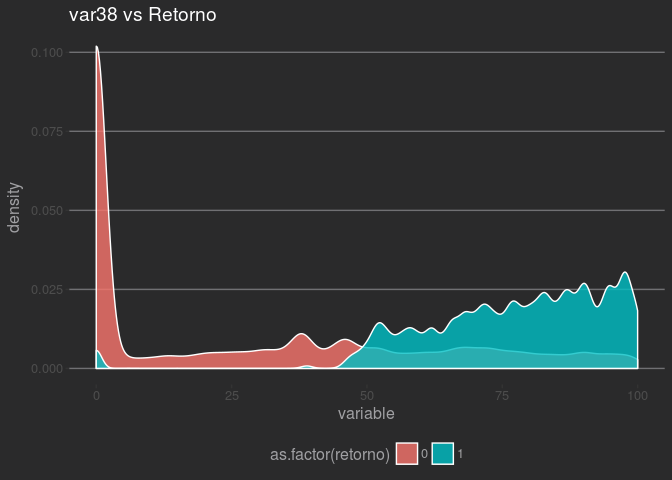

```r
# [] Confirmed Features
quickplot_density(full.data$var38)
```

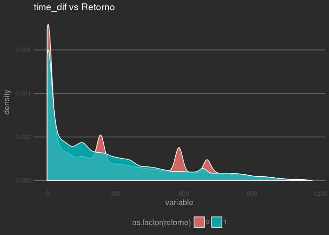

```r
quickplot_density(full.data$time_dif)
```

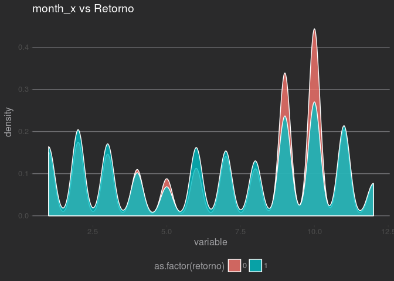

```r
quickplot_density(full.data$month_x)
```

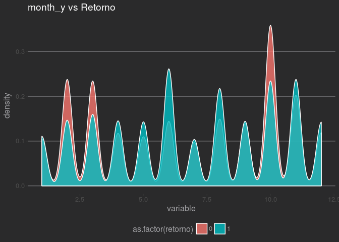

```r
quickplot_density(full.data$month_y)
```

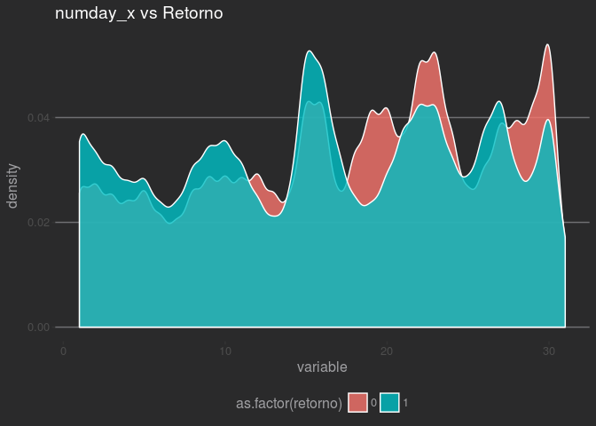

```r
quickplot_density(full.data$numday_x)
```

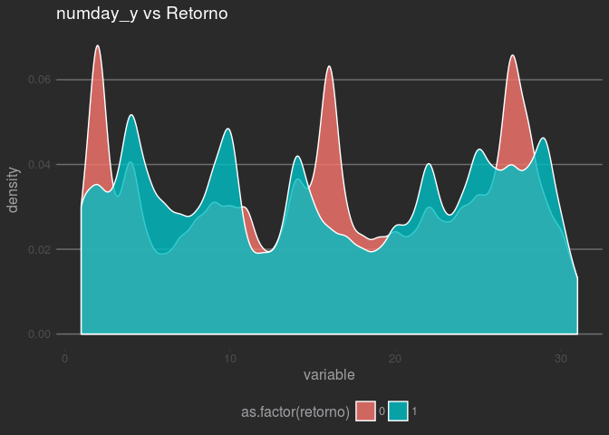

```r
quickplot_density(full.data$numday_y)
```

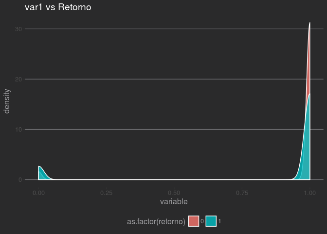

```r
quickplot_density(full.data$var1)
```

# Variáveis Rejeitadas

Aqui estão algumas das variáveis rejeitadas. Um caso em especial se refere à variável `past_result`. Com ela foi possível gerar um randomforest de 0.97+ auc… e por essa razão foi excluída do modelo final.

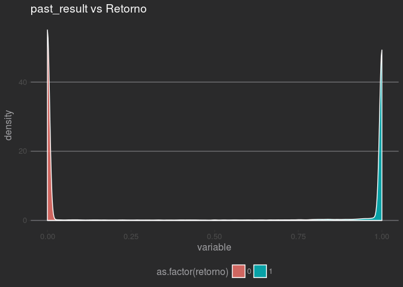

```r
# [] Special case: past_result
quickplot_density(full.data$past_result)
```

O uso crú dessa feature gera uma auc de 0.9786….

[figure not shown]

```r
#===================================================================================
# Being a Dick Approach
#===================================================================================
past_result$pred = round(past_result$past_result)

probe = fread("holdout_set2.csv") %>% as.data.frame()
probe = merge(probe, past_result, by="ID")
probe$retorno = ifelse(probe$retorno == "Sim",1,0)

glmnet::auc(probe$retorno, probe$pred) #0.9785612
```

A decisão por trás da exclusão se baseou em:

- 1. Todos os ids estão presentes nos dois sets, o que introduz um bias sistêmico sob a forma de data leak, na medida em que não há total independência entre o set de treino e teste, e logo seu potencial de generalização fica comprometido.
- 2. Por razões práticas, essa feature tomaria a importância das demais, o que causaria que comprometeria o funcionamento do modelo para clientes novos - em termos de negócio, esse modelo completamente excluiria novos clientes.

Demais variáveis rejeitadas:

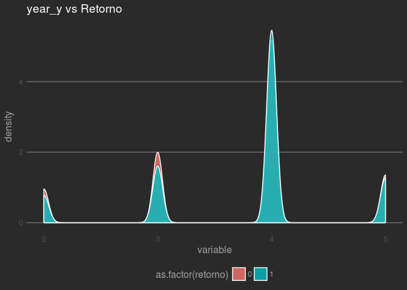

```r
# [] Rejected features
quickplot_density(full.data$year_y)
```

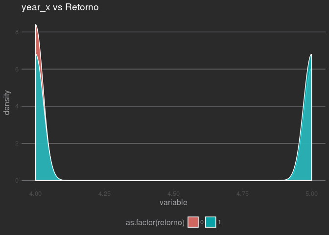

```r
quickplot_density(full.data$year_x)
```

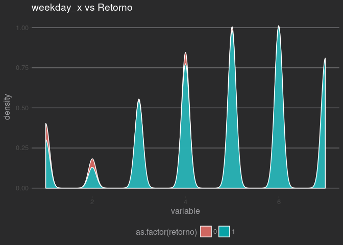

```r
quickplot_density(full.data$weekday_x)
```

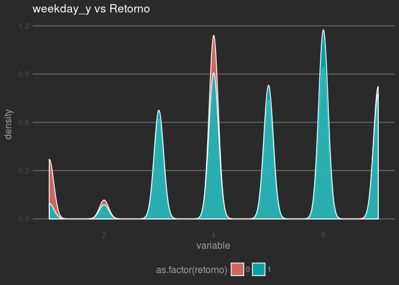

```r
quickplot_density(full.data$weekday_y)
```

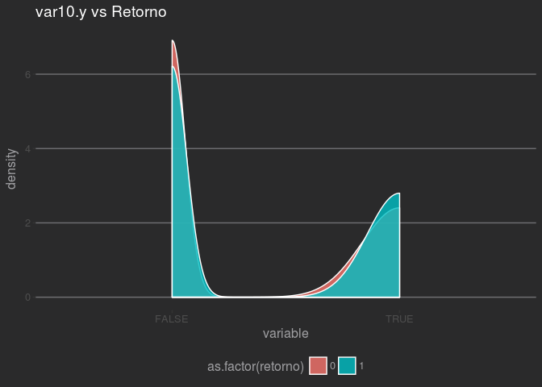

```r
quickplot_density(full.data$var10.y)
```

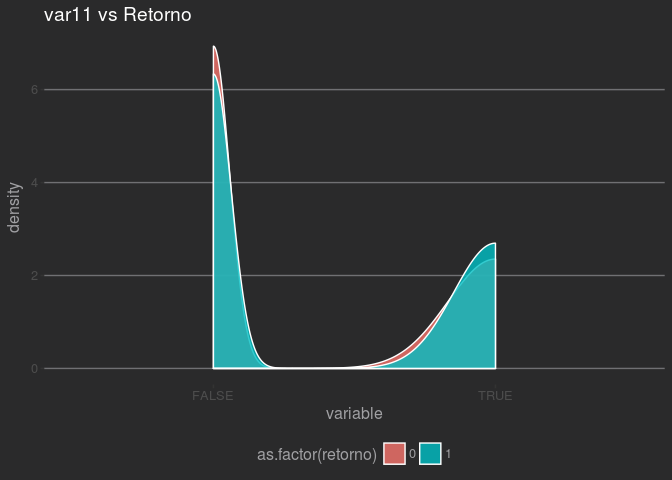

```r
quickplot_density(full.data$var11)
```

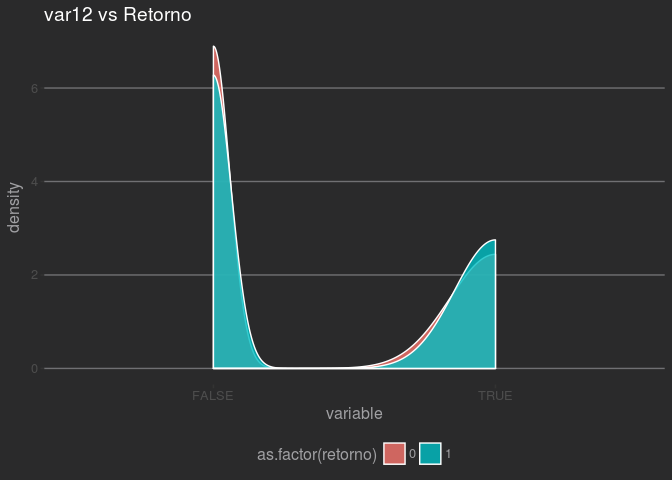

```r
quickplot_density(full.data$var12)
```

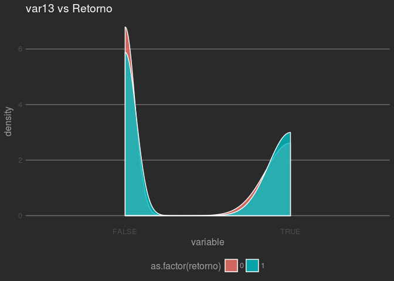

```r
quickplot_density(full.data$var13)
```

# Modelagem SemiFinal e Correção do Leak

Com as variáveis selecionadas e o leak identificado, é hora de modelar! Isolando as features selecionadas, podemos então fazer train/holdout split.

```r
# [] Isolate selected features
selected_features = c('retorno','var38','time_dif','month_x','month_y','numday_x','numday_y','var1','categoria') #'grupo' removed for too high RAM cost
full.data = full.data %>% as.data.frame()
training_data = full.data[,selected_features]

# [] Train / Holdout Split
splitr = sample.split(training_data$retorno, SplitRatio = 0.7)
train  = subset(training_data, splitr == TRUE)
probe  = subset(training_data, splitr == FALSE)

# [] Leak removal
truthfull.data = train[!duplicated(train$ID),]
truthfull.data$ID = NULL
```

Em seguida, criaremos um randomforest tunado com cross validation, treinado sobre o training set sem leak (`truthfull.data`) e validado duas vezes.

O cenário de data leakage é na realidade um dos mais preocupantes, na medida em que age na fonte de qualquer observação e pode facilmente inviabilizar uma análise ou modelo. Por essa razão, usei a dupla validação (cv + holdout) para garantir a integridade dos resultados.

Em relação á métrica escolhida, para aplicações práticas a `auc` pode conciliar diferentes necessidades de thresholds, como em fraude (um threshold para aviso e outro para bloqueio do cartão), além de naturalmente conduzir à acurácia. Sem um caso de uso ou entendimento do que é o target, creio que essa seria a melhor métrica.

```r
# [] Set CV Parameters and Grid
train.ctrl = trainControl(method="cv",number=4,classProbs=T,summaryFunction = twoClassSummary)
rf.grid    = expand.grid(mtry=c(3,4,5),
                         splitrule='gini',
                         min.node.size=1)

# [] Reencode targets (so caret won't crash)
train$retorno  = ifelse(train$retorno == 1,"Sim","Nao")
probe$retorno  = ifelse(probe$retorno == 1,"Sim","Nao")


# [] Train semifinal model (CV + Holdout validated)
rf.model = train(as.factor(retorno) ~ ., data=truthfull.data, method="ranger", num.trees=500,
                 trControl = train.ctrl, metric='ROC', tuneGrid = rf.grid) #0.83582
# [] Measure results
rf.pred = predict(rf.model, probe,type = 'prob')
table(probe$retorno, rf.pred$Sim >= 0.5)

probe$retorno  = ifelse(probe$retorno == "Sim",1,0)

glmnet::auc(probe$retorno, rf.pred$Sim) #0.833531
```

Este modelo serviu apenas para garantir alguma submissão, a essa altura faltavam menos de 30 minutos e eu não havia terminado o treinamento da rede neural e o ensemble feito em python. Optei por deixar eles treinando após criar esse modelo e depois atualizar esse markdown com os resultados.

Usando os mesmos dados e esquema de validação desse randomforest, criei um Lightgbm e uma rede neural em keras, com duas camadas e regularizada severamente com Dropout de 50%. Para elevar a velocidade de treino, utilizei inicialização HE e batch normalization.

EDIT:

Added meme

A combinação linear dos modelos obteve os seguintes resultados: (Holdout Set | AUC):

- Lightgbm: 0.8885450006107667
- DNN: 0.8862473179273296
- Linear Stacking: 0.8886615658398007

Para mais detalhes nesses modelos, por favor consulte o notebook. Obrigado!